# Indel Signature InsDel_N_alpha

# InsDel_Nα

(corresponds to 83-type signature ID_N)

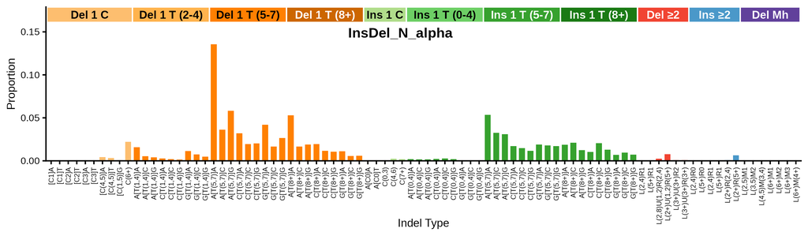

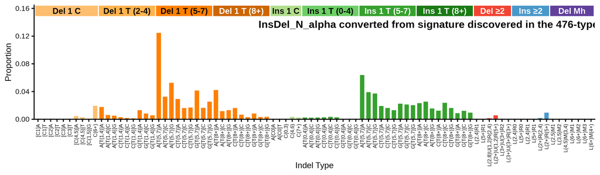

89-type spectrum of the linking tumor SP93227 | cosine similarity to InsDel_N_alpha: 0.984

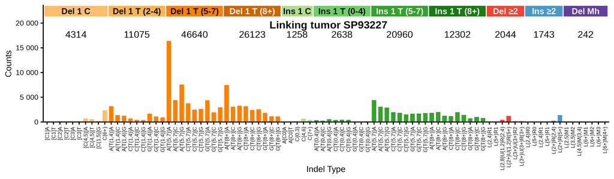

**Click to view decomposition of the linking tumor spectrum**

Partial mutation signature of SP93227 due to InsDel_N_alpha

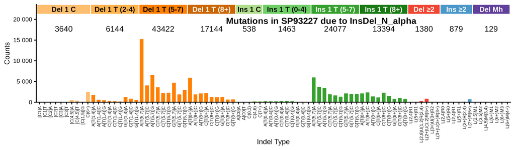

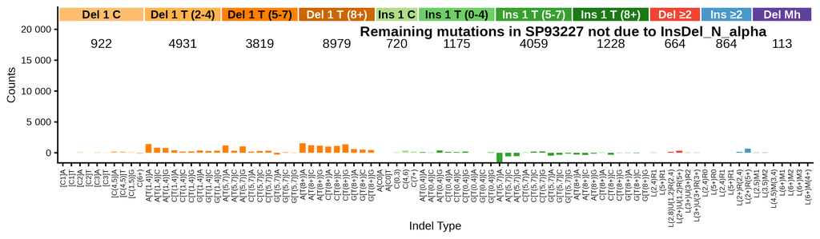

Max neg fraction (maximum allowed negative residual count as fraction of total): 0.04  
N subtract (mutation count assigned to signature): 112211.0  
N residual (mutation count in residual “partial spectrum”): 17128.0  
Total negative (sum of negative residual mutation counts): 5173.4  
N negative channels (number of channels with negative residual): 16  
P(≥ total negative) (Monte Carlo estimated probability that negative-binomial-sampled spectra from the signature contributing N subtract mutations would produce a total negative count >= the observed Total negative; higher number means not surprising): 0.935

**Per-channel residual breakdown**

| Channel | Spectrum | Sig_Count | Residual | Sig_Prop |
| --- | --- | --- | --- | --- |
| [Del(C):R1]A | 38 | 18.7 | 19.3 | 0.00017 |
| [Del(C):R1]T | 76 | 42.4 | 33.6 | 0.00038 |
| [Del(C):R2]A | 127 | 42.0 | 85 | 0.00037 |
| [Del(C):R2]T | 52 | 21.4 | 30.6 | 0.00019 |
| [Del(C):R3]A | 115 | 42.2 | 72.8 | 0.00038 |
| [Del(C):R3]T | 65 | 26.1 | 38.9 | 0.00023 |
| [Del(C):R(4,5)]A | 722 | 493.6 | 228.4 | 0.00440 |
| [Del(C):R(4,5)]T | 558 | 357.9 | 200.1 | 0.00319 |
| [Del(C):R(1,5)]G | 195 | 105.4 | 89.6 | 0.00094 |
| Del(C):R(6,9) | 2366 | 2490.2 | -124.2 | 0.02219 |
| A[Del(T):R(1,4)]A | 3195 | 1768.0 | 1427 | 0.01576 |
| A[Del(T):R(1,4)]C | 1411 | 596.6 | 814.4 | 0.00532 |
| A[Del(T):R(1,4)]G | 1247 | 459.9 | 787.1 | 0.00410 |
| C[Del(T):R(1,4)]A | 703 | 295.6 | 407.4 | 0.00263 |
| C[Del(T):R(1,4)]C | 430 | 217.9 | 212.1 | 0.00194 |
| C[Del(T):R(1,4)]G | 380 | 152.5 | 227.5 | 0.00136 |
| G[Del(T):R(1,4)]A | 1673 | 1274.0 | 399 | 0.01135 |
| G[Del(T):R(1,4)]C | 1128 | 828.8 | 299.2 | 0.00739 |
| G[Del(T):R(1,4)]G | 908 | 550.7 | 357.3 | 0.00491 |
| A[Del(T):R(5,7)]A | 16389 | 15210.7 | 1178.3 | 0.13555 |
| A[Del(T):R(5,7)]C | 4427 | 4069.2 | 357.8 | 0.03626 |
| A[Del(T):R(5,7)]G | 7564 | 6520.7 | 1043.3 | 0.05811 |
| C[Del(T):R(5,7)]A | 3791 | 3589.2 | 201.8 | 0.03199 |
| C[Del(T):R(5,7)]C | 2487 | 2194.0 | 293 | 0.01955 |
| C[Del(T):R(5,7)]G | 2644 | 2287.5 | 356.5 | 0.02039 |
| G[Del(T):R(5,7)]A | 4401 | 4696.7 | -295.7 | 0.04186 |
| G[Del(T):R(5,7)]C | 1957 | 1869.5 | 87.5 | 0.01666 |
| G[Del(T):R(5,7)]G | 2980 | 2984.8 | -4.8 | 0.02660 |
| A[Del(T):R(8,)]A | 7479 | 5930.1 | 1548.9 | 0.05285 |
| A[Del(T):R(8,)]C | 3091 | 1873.8 | 1217.2 | 0.01670 |

[output cut: 59 more lines]

**Click to view similar signatures from Koh et al.**

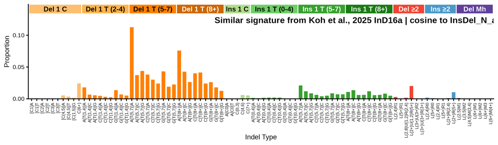

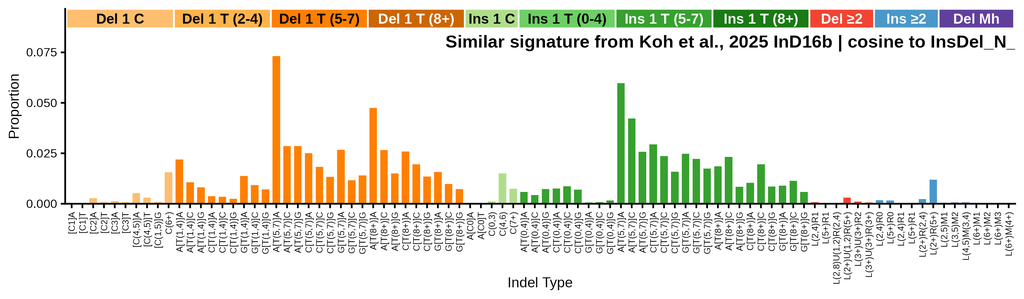

## 476-type representations corresponding to InsDel_N_alpha

Extracted 476-type signature corresponding to InsDel_N_alpha

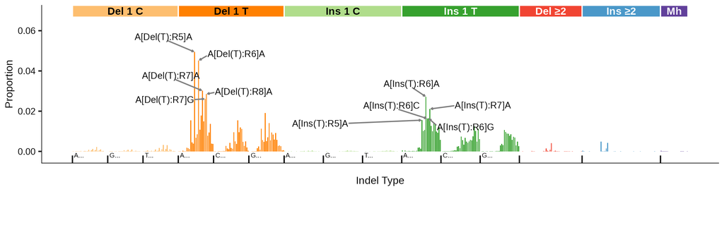

476-type spectrum of the linking tumor SP93227; cosine similarity to the extracted 476-type signature is 0.9497

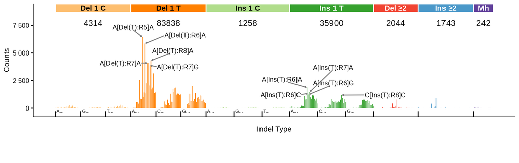

476-type spectrum of best 476-type matching tumor SP90209; cosine similarity to the extracted 476-type signature is 0.9522

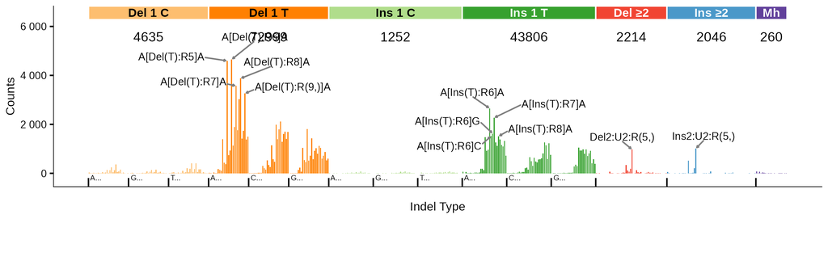

## 83-type signature corresponding to InsDel_N_alpha (ID_N)

**Note**

ID_N can be decomposed into C_ID1 and C_ID2. Nevertheless, We think it is a novel signature rather than a combination of two signatures because (1) it was found in both SigProfiler and mSigHdp and (2) we found the corresponding 89-type/476-type signatures (InsDel_N_alpha and InsDel_N_beta).

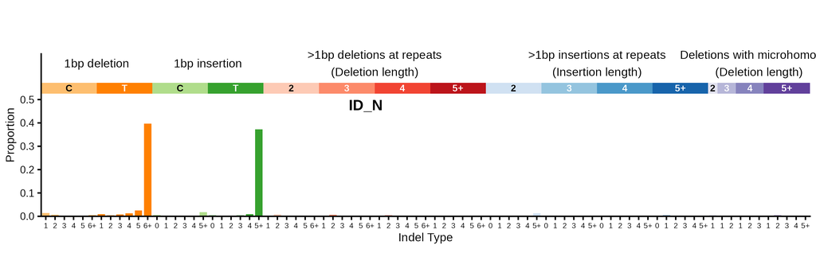

**Click here to see with insertions and deletions of T in long poly-T suppressed**

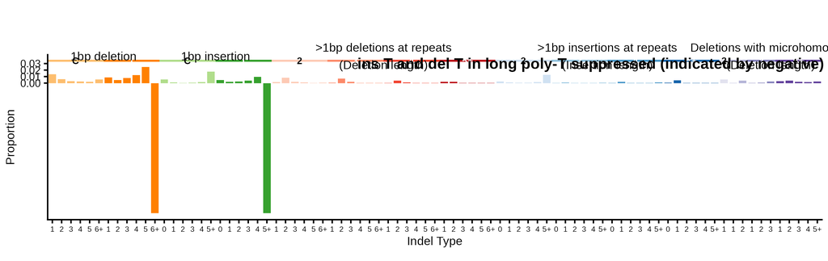

83-type signature converted from signature discovered in the 476-type spectra (using bipartite matching optimization) | cosine similarity to ID_N: 0.9824

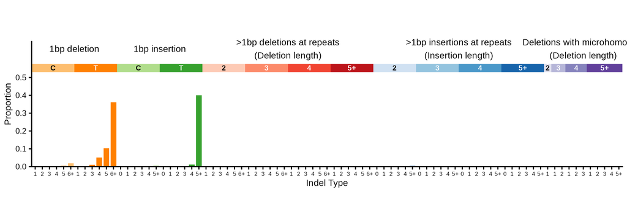

**Click here to see with insertions and deletions of T in long poly-T suppressed**

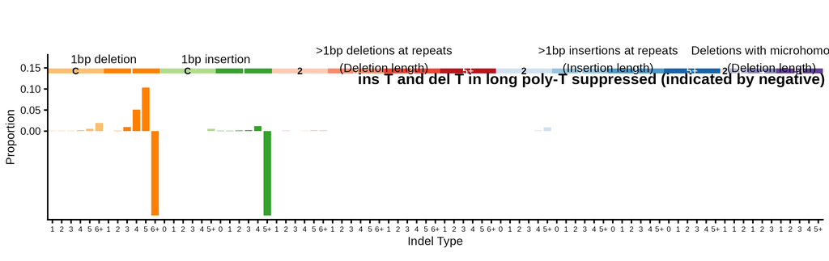

**Click to see flow diagrams: 476-type to 83-type collapse**

These Sankey diagrams show how the 476-type mutation categories are redistributed to 83-type categories using bipartite matching. We only show the diagrams for insertions or deletions of > 1 base because it is for these indels that 476-type categories map to > 1 83-type category.

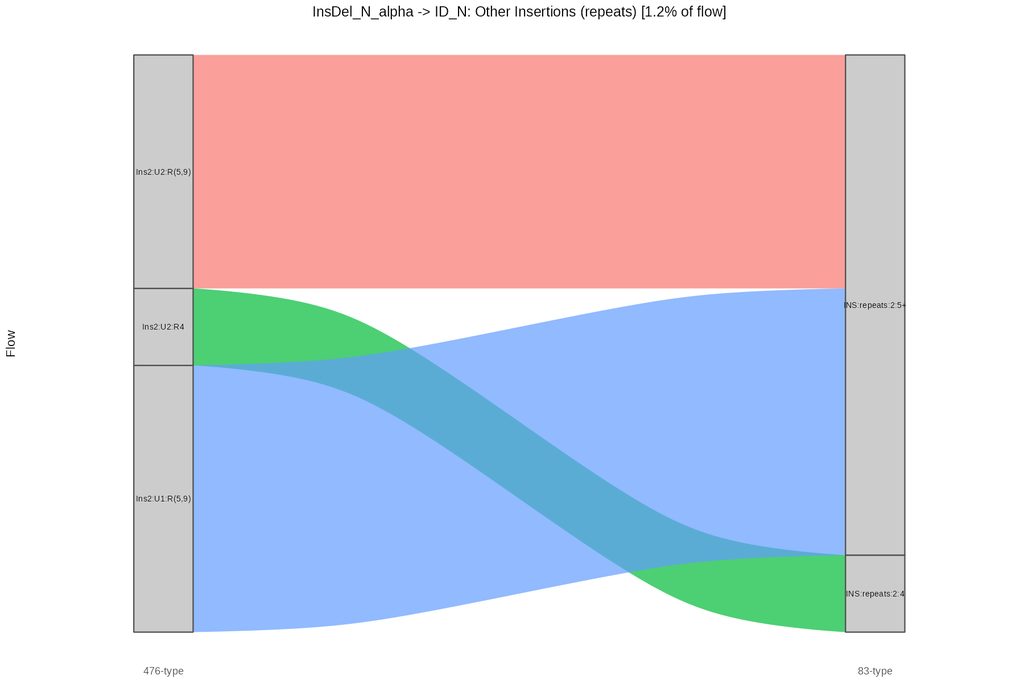

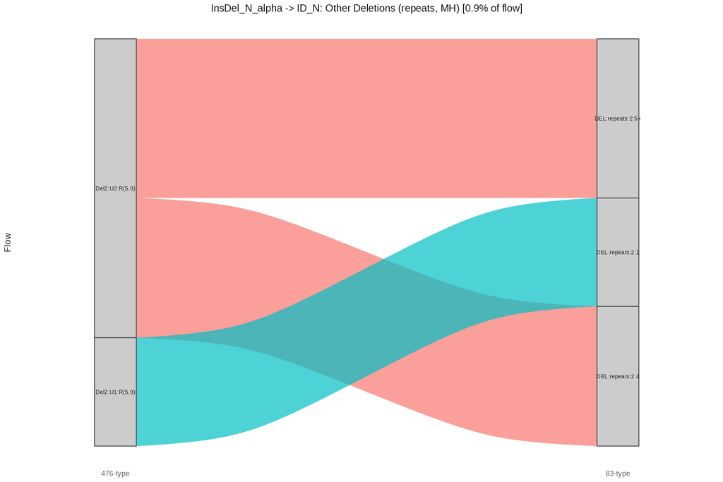

83-type spectrum of the linking tumor SP93227 | cosine similarity to ID_N: 0.954

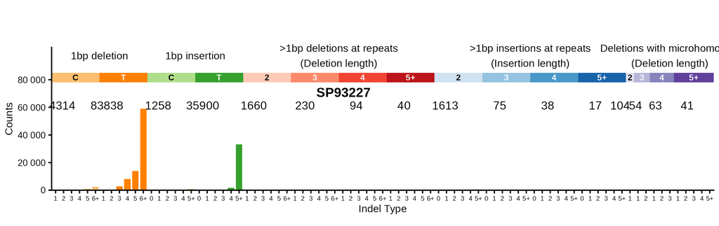

**Click here to see with insertions and deletions of T in long poly-T suppressed**

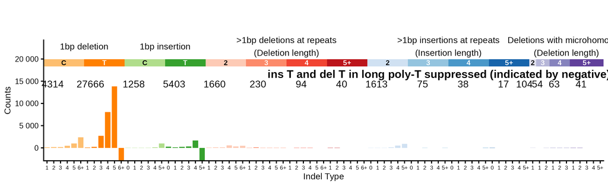

83-type spectrum of best 83-type matching tumor SP111038 | cosine similarity to ID_N: 0.9991

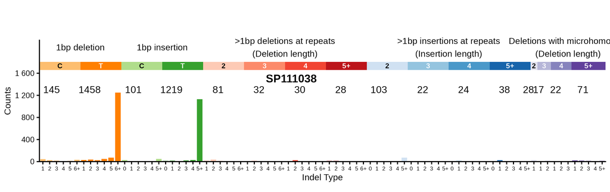

**Click here to see with insertions and deletions of T in long poly-T suppressed**

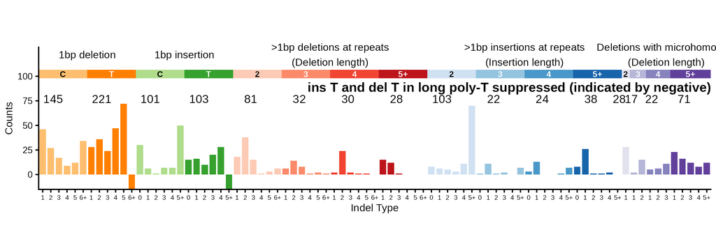